# Convolutional Neural Networks

## Project: Write an Algorithm for Landmark Classification

### Introduction

The project folder has the following structure:

- In the main directory you have this notebook, `cnn_from_scratch.ipynb`, that contains the instruction and some questions with answers.
- In the `/src` directory you have several source files.

### Designing and training a CNN from scratch

In this notebook, we will create a CNN that classifies landmarks with a test accuracy of 54%.

Although 50% may seem low at first glance, it seems more reasonable after realizing how difficult of a problem this is. Many times, an image that is taken at a landmark captures a fairly mundane image of an animal or plant, like in the following picture.

[figure not shown]

Just by looking at that image alone, would you have been able to guess that it was taken at the Haleakalā National Park in Hawaii?

## Step 0: Setting up

[figure not shown]

```python
# Install requirements
!pip install -r requirements.txt | grep -v "already satisfied"
```

```python
import logging
logging.basicConfig(level=logging.INFO, force=True)
logging.info("Works!")
```

```
INFO:root:Works!
```

```python
from src.helpers import setup_env

# If running locally, this will download dataset (make sure you have at
# least 2 Gb of space on your hard drive)
setup_env()
```

```
INFO:helpers:GPU *NOT* available. Will use CPU (slow)
INFO:helpers:Downloading and unzipping https://udacity-dlnfd.s3-us-west-1.amazonaws.com/datasets/landmark_images.zip. This will take a while...
INFO:helpers:done
INFO:helpers:Reusing cached mean and std. Mean: tensor([0.4638, 0.4725, 0.4687]), std: tensor([0.2699, 0.2706, 0.3018])
```

## Step 1: Data

[figure not shown]

In this and the following steps we are going to complete some code, and then execute some tests to make sure the code works as intended.

```python
!pytest -vv data.py -k data_loaders
```

```
======================================= test session starts ========================================
platform linux -- Python 3.10.12, pytest-7.4.4, pluggy-1.5.0 -- /usr/bin/python3
cachedir: .pytest_cache
rootdir: /content
plugins: anyio-3.7.1
collected 4 items / 1 deselected / 3 selected

data.py::test_data_loaders_keys PASSED                                                       [ 33%]
data.py::test_data_loaders_output_type PASSED                                                [ 66%]
data.py::test_data_loaders_output_shape PASSED                                               [100%]

================================= 3 passed, 1 deselected in 5.29s ==================================
```

**Question:** Describe your chosen procedure for preprocessing the data.

- How does your code resize the images (by cropping, stretching, etc)? What size did you pick for the input tensor, and why?
- Did you decide to augment the dataset? If so, how (through translations, flips, rotations, etc)? If not, why not?

**Answer**: My code first resizes the image to 256 and then crops to 224. I picked 224 as the input size because it is the recommended input size for using pytorch's pre-trained models. I decide to augment the dataset via horizontal flip & RandAugment(2, 10), a typical set of augmentations for natural images. I added this augmentation with the goal of improving my model's robustness, thus improving test accuracy.

### Visualize a Batch of Training Data

```python
!pytest -vv data.py -k visualize_one_batch
```

```
======================================= test session starts ========================================
platform linux -- Python 3.10.12, pytest-7.4.4, pluggy-1.5.0 -- /usr/bin/python3
cachedir: .pytest_cache
rootdir: /content
plugins: anyio-3.7.1
collected 4 items / 3 deselected / 1 selected

data.py::test_visualize_one_batch PASSED                                                     [100%]

================================= 1 passed, 3 deselected in 4.09s ==================================
```

We can now use the code we just completed to get a batch of images from your train data loader and look at them.

Visualizing the output of your data loader is a great way to ensure that your data loading and preprocessing (including transforms such as rotations, translations, color transforms...) are working as expected.

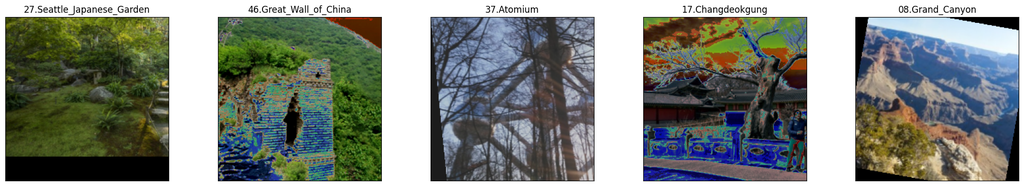

```python
%matplotlib inline
from src.data import visualize_one_batch, get_data_loaders

# use get_data_loaders to get the data_loaders dictionary. Use a batch_size
# of 5, a validation size of 0.01 and num_workers=-1 (all CPUs)
data_loaders = get_data_loaders(batch_size=5, valid_size=0.01, num_workers=-1)

visualize_one_batch(data_loaders)
```

## Step 2: Define model

[figure not shown]

```python
!pytest -vv model.py
```

```
======================================= test session starts ========================================
platform linux -- Python 3.10.12, pytest-7.4.4, pluggy-1.5.0 -- /usr/bin/python3
cachedir: .pytest_cache
rootdir: /content
plugins: anyio-3.7.1
collected 1 item

model.py::test_model_construction PASSED                                                     [100%]

======================================== 1 passed in 3.58s =========================================
```

**Question**: Outline the steps you took to get to your final CNN architecture and your reasoning at each step.

**Answer:** I decided to use 6 convolutional layers so that my model could be sufficiently expressive, using convolutional layers along with max-pooling layers to extract abstract features from the input images. I used ReLU activation functions to introduce non-linearity into the model. I used batch normalization to speed up training and reduce overfitting. I used dropout layers to reduce my model's tendency to overfit the training data. I made my model output a 50-dimensional vector to match with the 50 available landmark classes.

## Step 3: define loss and optimizer

[figure not shown]

```python
!pytest -vv optimization.py -k get_loss
```

```
======================================= test session starts ========================================
platform linux -- Python 3.10.12, pytest-7.4.4, pluggy-1.5.0 -- /usr/bin/python3
cachedir: .pytest_cache
rootdir: /content
plugins: anyio-3.7.1
collected 7 items / 6 deselected / 1 selected

optimization.py::test_get_loss PASSED                                                        [100%]

================================= 1 passed, 6 deselected in 1.40s ==================================
```

```python
!pytest -vv optimization.py -k get_optimizer
```

```
======================================= test session starts ========================================
platform linux -- Python 3.10.12, pytest-7.4.4, pluggy-1.5.0 -- /usr/bin/python3
cachedir: .pytest_cache
rootdir: /content
plugins: anyio-3.7.1
collected 7 items / 1 deselected / 6 selected

optimization.py::test_get_optimizer_type PASSED                                              [ 16%]
optimization.py::test_get_optimizer_is_linked_with_model PASSED                              [ 33%]
optimization.py::test_get_optimizer_returns_adam PASSED                                      [ 50%]
optimization.py::test_get_optimizer_sets_learning_rate PASSED                                [ 66%]
optimization.py::test_get_optimizer_sets_momentum PASSED                                     [ 83%]
optimization.py::test_get_optimizer_sets_weight_decat PASSED                                 [100%]

================================= 6 passed, 1 deselected in 3.19s ==================================
```

## Step 4: Train and Validate the Model

[figure not shown]

```python
!pytest -vv train.py -k train_one_epoch
```

```
======================================= test session starts ========================================
platform linux -- Python 3.10.12, pytest-7.4.4, pluggy-1.5.0 -- /usr/bin/python3
cachedir: .pytest_cache
rootdir: /content
plugins: anyio-3.7.1
collected 4 items / 3 deselected / 1 selected

train.py::test_train_one_epoch PASSED                                                        [100%]

================================= 1 passed, 3 deselected in 6.64s ==================================
```

```python
!pytest -vv train.py -k valid_one_epoch
```

```
======================================= test session starts ========================================
platform linux -- Python 3.10.12, pytest-7.4.4, pluggy-1.5.0 -- /usr/bin/python3
cachedir: .pytest_cache
rootdir: /content
plugins: anyio-3.7.1
collected 4 items / 3 deselected / 1 selected

train.py::test_valid_one_epoch PASSED                                                        [100%]

================================= 1 passed, 3 deselected in 6.47s ==================================
```

```python
!pytest -vv train.py -k optimize
```

```
======================================= test session starts ========================================
platform linux -- Python 3.10.12, pytest-7.4.4, pluggy-1.5.0 -- /usr/bin/python3
cachedir: .pytest_cache
rootdir: /content
plugins: anyio-3.7.1
collected 4 items / 3 deselected / 1 selected

train.py::test_optimize PASSED                                                               [100%]

================================= 1 passed, 3 deselected in 8.43s ==================================
```

```python
!pytest -vv train.py -k one_epoch_test
```

```
======================================= test session starts ========================================
platform linux -- Python 3.10.12, pytest-7.4.4, pluggy-1.5.0 -- /usr/bin/python3
cachedir: .pytest_cache
rootdir: /content
plugins: anyio-3.7.1
collected 4 items / 3 deselected / 1 selected

train.py::test_one_epoch_test PASSED                                                         [100%]

================================= 1 passed, 3 deselected in 5.50s ==================================
```

## Step 5: Putting everything together

[figure not shown]

In the following cell we will train the model and validate it against the validation set.

Let's start by defining a few hyperparameters. Feel free to experiment with different values and try to optimize the model:

```python
batch_size = 64        # size of the minibatch for stochastic gradient descent (or Adam)
valid_size = 0.2       # fraction of the training data to reserve for validation
num_epochs = 50        # number of epochs for training
num_classes = 50       # number of classes. Do not change this
dropout = 0.4          # dropout for our model
learning_rate = 0.001  # Learning rate for SGD (or Adam)
opt = 'sgd'            # optimizer. 'sgd' or 'adam'
weight_decay = 0.0     # regularization. Increase this to combat overfitting
momentum = 0.9         # momentum for SGD
```

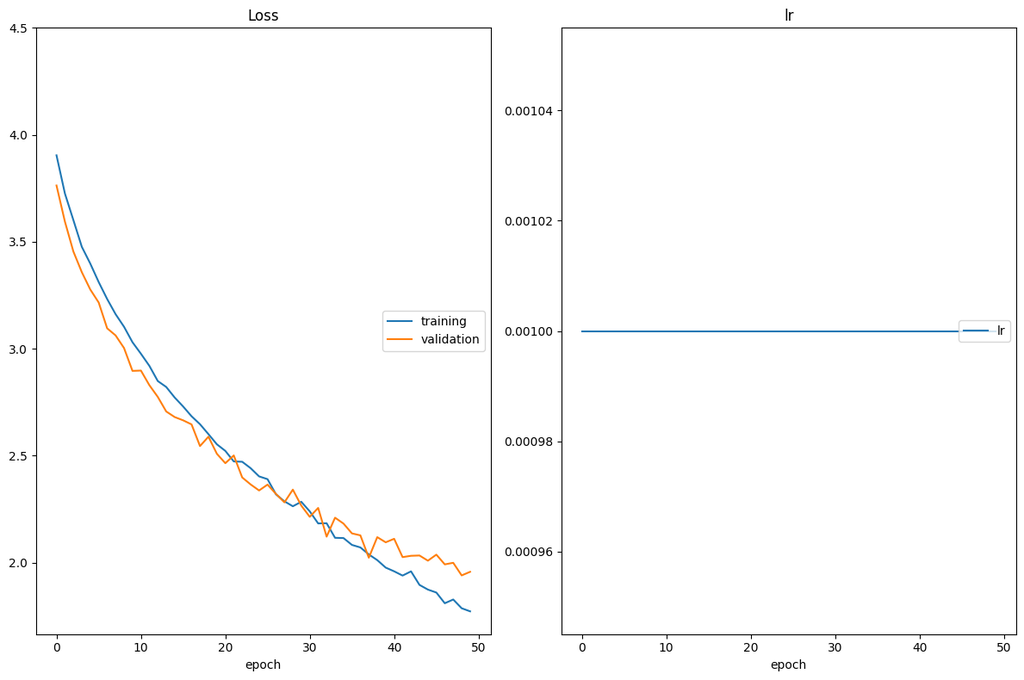

```python
from src.data import get_data_loaders
from src.train import optimize
from src.optimization import get_optimizer, get_loss
from src.model import MyModel

# get the data loaders using batch_size and valid_size defined in the previous
# cell
data_loaders = get_data_loaders(batch_size=batch_size, valid_size=valid_size)

# instance model MyModel with num_classes and drouput defined in the previous
# cell
model = MyModel(num_classes=num_classes, dropout=dropout)

# Get the optimizer using get_optimizer and the model we just created, the learning rate,
# the optimizer and the weight decay specified in the previous cell
optimizer = get_optimizer(model=model, learning_rate=learning_rate,
                          optimizer=opt, weight_decay=weight_decay, momentum=momentum)

# Get the loss using get_loss
loss = get_loss()

optimize(
    data_loaders,
    model,
    optimizer,
    loss,
    n_epochs=num_epochs,
    save_path="checkpoints/best_val_loss.pt",
    interactive_tracking=True
)
```

## Step 6: testing against the Test Set

[figure not shown]

> only run this *after* you have completed hyperpameter optimization. Do not optimize hyperparameters by looking at the results on the test set, or you might overfit on the test set (bad, bad, bad)

```python
# load the model that got the best validation accuracy
from src.train import one_epoch_test
from src.model import MyModel
import torch

model = MyModel(num_classes=num_classes, dropout=dropout)

model.load_state_dict(torch.load("checkpoints/best_val_loss.pt", map_location='cpu'))

# Run test
one_epoch_test(data_loaders['test'], model, loss)
```

```
INFO:model:Number of input features to the classifier: 4608, hidden nodes: 512
INFO:model:Model has  3,961,266 parameters
INFO:train:Test Loss: 1.778927

INFO:train:
Test Accuracy: 54% (684/1250)
```

```
1.7789273597227406
```

## Step 7: Export using torchscript

[figure not shown]

```python
!pytest -vv predictor.py
```

```
======================================= test session starts ========================================
platform linux -- Python 3.10.12, pytest-7.4.4, pluggy-1.5.0 -- /usr/bin/python3
cachedir: .pytest_cache
rootdir: /content
plugins: anyio-3.7.1
collected 1 item

predictor.py::test_model_construction PASSED                                                 [100%]

======================================== 1 passed in 3.25s =========================================
```

Allright, now we are ready to export our model using our Predictor class:

```python
from src.predictor import Predictor
from src.helpers import compute_mean_and_std
from src.model import MyModel
from src.data import get_data_loaders
import torch

data_loaders = get_data_loaders(batch_size=1)

# First let's get the class names from our data loaders
class_names = data_loaders["train"].dataset.classes

# Then let's move the model_transfer to the CPU
# (we don't need GPU for inference)
model = MyModel(num_classes=50, dropout=0.5).cpu()

# Let's make sure we use the right weights by loading the
# best weights we have found during training
# we use map_location='cpu' so the weights are loaded on the CPU (and not the GPU)
model.load_state_dict(torch.load("checkpoints/best_val_loss.pt", map_location='cpu'))

# wrap our model using the predictor class
mean, std = compute_mean_and_std()
predictor = Predictor(model, class_names, mean, std).cpu()

# Export using torch.jit.script
scripted_predictor = torch.jit.script(predictor)

scripted_predictor.save("checkpoints/original_exported.pt")
```

```
INFO:data:Using 2 workers
INFO:helpers:Data folder: landmark_images
INFO:helpers:Reusing cached mean and std. Mean: tensor([0.4638, 0.4725, 0.4687]), std: tensor([0.2699, 0.2706, 0.3018])
INFO:data:Dataset mean: tensor([0.4638, 0.4725, 0.4687]), std: tensor([0.2699, 0.2706, 0.3018])
INFO:model:Number of input features to the classifier: 4608, hidden nodes: 512
INFO:model:Model has  3,961,266 parameters
INFO:helpers:Reusing cached mean and std. Mean: tensor([0.4638, 0.4725, 0.4687]), std: tensor([0.2699, 0.2706, 0.3018])
```

Now let's make sure the exported model has the same performance as the original one, by reloading it and testing it. The Predictor class takes different inputs than the non-wrapped model, so we have to use a specific test loop:

```python
import torch

# Load using torch.jit.load
model_reloaded =  torch.jit.load("checkpoints/original_exported.pt")
```

```python
from src.predictor import predictor_test

pred, truth = predictor_test(data_loaders['test'], model_reloaded)
```

```
INFO:helpers:Data folder: landmark_images
INFO:predictor:Accuracy: 0.548
```

Finally, let's have a look at the confusion matrix of the model we are going to use in production:

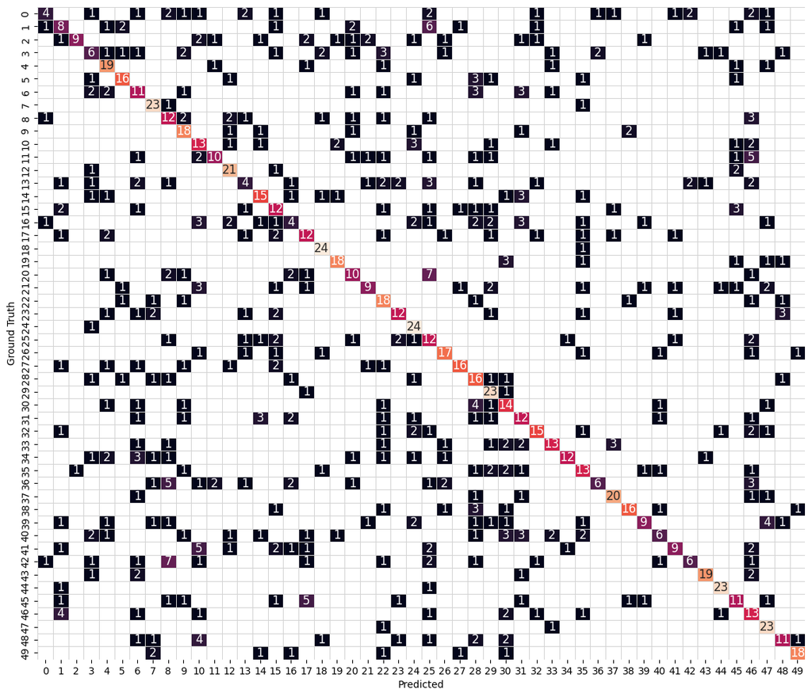

```python
from src.helpers import plot_confusion_matrix

plot_confusion_matrix(pred, truth)
```